# Soil minerals mediate climatic control of soil C cycling on annual to centennial timescales

Jeffrey Beem-Miller

1  
jbeem@bgc-jena.mpg.de

Craig Rasmussen

2

Alison M. Hoyt

1,3

Marion Schrumpf

1

Georg Guggenberger

4

Susan Trumbore

1

Abstract

[output not shown]

(ref:site-data-t1-cap) Soil and climate data by site.

# Key messages:

- Mineral assemblages mediate climatic control of fast and slow cycling soil C
- Poorly crystalline, not crystalline, metal oxide abundance correlates with <sup>14</sup>C of bulk soil and respired CO<sub>2</sub>
- Climate controls surface soil C dynamics; mineral assemblage is more important at depth

# Introduction

Understanding the response of soil carbon stocks to current and future changes in climate requires insight into both the physical and environmental factors governing soil carbon dynamics. Climate, and in particular temperature, has been found to be the most important variable for explaining the age of soil carbon in topsoil at local to global scales [Frank et al., 2012; Mathieu et al., 2015; Shi et al. 2020]. Yet our current understanding of soil organic matter decomposition underscores the importance of physical mechanisms that can affect the temperature sensitivity of decomposition, such as the interaction between soil organic matter and minerals [Davidson et al., 2000; Davidson and Janssens, 2006; Rasmussen et al., 2006; Lehmann and Kleber, 2015;]. The effect of mineral-organic associations on the temperature sensitivity of soil organic matter has been addressed in several modeling studies [Abramoff et al., 2019; Riley et al., 2016; Ahrens et al., 2015; Woolf and Lehmann, 2019]. These models typically invoke Michaelis Menten kinetics in addition to an Arrhenius-type temperature response in order to account for energy and substrate limitations on decomposition rates of soil organic matter found in association with minerals [Tang and Riley, 2019; Ahrens et al., 2020]. Studies comparing the relative importance of different soil mineral assemblages versus temperature for explaining soil C dynamics over time *in situ* are scarce, yet critical for testing these model-based findings. We designed the current study to quantify the relative importance of climatic versus mineralogical mechanisms of soil organic C persistence across a combined gradient of mean annual temperature (MAT) and parent material in order to provide insight into the relevant time scales associated with these mechanisms.

The strength and sorptive capacity of soil minerals is dependent on ligand exchange, which is a function of not only surface area and charge, but more specifically the density of accessible hydroxyl groups (Kaiser and Guggenberger, 2003; Rasmussen et al., 2018a “Beyond Clay”; Kleber et al., 2015). Poorly crystalline metal oxides are particularly enriched in hydroxyl groups, and batch sorption/desorption experiments have shown that the mineral-organic interactions between pedogenic metal oxide-rich clays are stronger than those with siloxane-rich phyllosilicate clays (Kahle et al., 2004). Furthermore, the reactive properties of pedogenic metal oxides can also facilitate lower strength interactions with soil organic matter through multivalent cation bridging (Kleber et al., 2007). This high reactivity of poorly crystalline Fe oxides is also implicated in the observations that poorly crystalline Fe is correlated with aggregate stability but crystalline Fe oxide content is not (Duiker et al., 2003). The importance of pedogenic metal oxides for explaining both soil C concentration and bulk soil radiocarbon ($\Delta$<sup>14</sup>C<sub>*bulk*</sub>) is confirmed by the findings of Rasmussen et al. (Soil systems, 2018a; Torn et al. 1997), who observed that oxalate extractable iron was the best predictor of both properties. However, the relevance of mineral-organic associations with specific mineral phases such as poorly crystalline metal oxides or crystalline metal oxides for specific timescales of soil C turnover is poorly studied.

Radiocarbon (<sup>14</sup>C) is a useful tracer for soil C dynamics over time scales ranging from annual to millennial. The use of <sup>14</sup>C to measure timescales of soil carbon decomposition is reliant on our knowledge of the ratio of <sup>12</sup>C/<sup>14</sup>C in the atmosphere. Once CO<sub>2</sub> is fixed into organic matter via photosynthesis, this ratio starts to shift as <sup>14</sup>C is lost due to radioactive decay. Changes in the <sup>12</sup>C/<sup>14</sup>C ratio due to radioactive decay are detectable at the relatively longer timescales of hundreds to thousands of years. However, we can detect changes in <sup>14</sup>C with nearly annual resolution for the so-called “bomb-C” period, which began with the deployment and atmospheric testing of nuclear weapons in the mid-20<sup>th</sup> century. This pulse of “bomb-C” led to a doubling of atmospheric <sup>14</sup>C concentration prior to the ban on above-ground nuclear tests in 1963. The level of <sup>14</sup>C in the atmosphere returned to pre-bomb levels around 2020 (Hua et al., 2021), thus archived samples now represent the best opportunity to construct a high-resolution time series of the bomb-C pulse as it moves through different soil organic matter pools.

Soil is an open system, and this has important implications for the interpretation of radiocarbon measurements of soil C. For most soils, the majority of carbon that enters the soil leaves relatively quickly, with only a small fraction persisting (Sierra et al. 2018). Radiocarbon measurements of bulk soil C ($\Delta$<sup>14</sup>C<sub>*bulk*</sub>) typically capture the signal from these persistent pools, while more transient pools dominate measurements of C leaving the soil via heterotrophic respiration (Trumbore 2000). Here we define “transient” for C cycling on annual to decadal timescales, while we use “persistent” to refer to C cycling on centennial to millennial timescales. A diagnostic feature of the radiocarbon measurements of $\Delta$<sup>14</sup>C<sub>*bulk*</sub> and heterotrophically respired CO<sub>2</sub> ($\Delta$<sup>14</sup>C<sub>*respired*</sub>) is that when these two signals are the same it indicates that all of the C in the soil has an equal probability of being decomposed by microbes and the system is homogenous. However, when $\Delta$<sup>14</sup>C<sub>*bulk*</sub> and $\Delta$<sup>14</sup>C<sub>*respired*</sub> are substantially different, this indicates the presence of both labile and persistent pools of soil C.

We were able to construct a time series of both $\Delta$<sup>14</sup>C<sub>*bulk*</sub> and $\Delta$<sup>14</sup>C<sub>*respired*</sub> at these sites by combining data from samples newly collected in 2019 with data from archived samples collected in 2001 and 2009. Such a time series provides a crucial constraint for determining the trajectory of bomb-derived <sup>14</sup>C concentrations over time (Beem-Miller et al., 2020; Stoner et al., 2020). Whether bomb-C concentrations are increasing or decreasing with time depends on the distribution of soil C among pools with different cycling rates as well as the year in which the soil was sampled, and thus cannot be easily determined from observations at a single point in time (Baisden et al. 2003). Using the radiocarbon time series in combination with previously determined mineralogical data, we were able to test several hypotheses regarding the roles of mineralogical versus climatic factors in determining both overall cycling rates and the dynamics of transiently cycling soil C.

We can expect soils with large stocks of persistent soil C to have depleted values of $\Delta$<sup>14</sup>C<sub>*bulk*</sub> relative to soils dominated by fast cycling soil C. If climate proves more important than parent material for determining soil C persistence, then we would expect to see large differences in $\Delta$<sup>14</sup>C<sub>*bulk*</sub> among climate regimes when comparing soils within a given parent material, but minimal differences among parent materials when comparing soils within the same climate regime. However, if parent material proves more important than climate for soil C persistence, we would expect the opposite trends in $\Delta$<sup>14</sup>C<sub>*bulk*</sub>: differences would be greater among parent materials within a given climate regime than among climate regimes within a given parent material. Alternatively, if persistent soil C is associated with specific soil minerals, we would expect an interactive effect of parent material and climate on $\Delta$<sup>14</sup>C<sub>*bulk*</sub>. For example, if soil C persistence is due to the association of soil organic matter with poorly crystalline metal oxides, we would expect to observe the most depleted $\Delta$<sup>14</sup>C<sub>*bulk*</sub> values where the combination of parent material and climate factors has led to the greatest abundance of these specific soil minerals.

# Methods

## Sample collection

Site locations were initially established in 2001 by C. Rasmussen (Rasmussen et al., 2006), and resampled in 2009 (Rasmussen et al., 2018) and 2019 (this study). Three replicate pits were dug to the depth of the B horizon (2001 sampling), or down to the C horizon (2009 and 2019 sampling). Samples were collected from the pit sidewalls by horizon in 2001 and 2009, and by 0.1 m increments in 2019. For the 2019 resampling, we located the sites using GPS and geospatial coordinates recorded during site establishment. Prior to sample collection we compared the soil profiles to the pedon descriptions from the 2001 sampling campaign to confirm the profiles matched. In 2019 we also measured the depth of the litter layer and collected representative litter samples from each site. However, we only focus on the upper mineral soil layers in this study (0 to ca. 0.3m) as the 2001 sampling was restricted to this depth range.

## Incubations

Laboratory soil incubations were performed on composite samples from the three replicate pedons sampled at each site in 2001 and 2019. We omitted the 2009 samples from the incubation experiment to save on time and analysis costs, and because sample material was only available from a single profile at each site. We composited and incubated each depth increment separately in 1 L glass mason jars fitted with air tight sampling ports in the lids. Incubations were performed in duplicate. Prior to the start of incubations we adjusted the soil moisture content to 60% of water holding capacity (WHC). Samples from 2001 were air-dried prior to archiving, and therefore we also air-dried the freshly collected soils from 2019 in order to control for the known effects of drying and rewetting on $\Delta$<sup>14</sup>C<sub>*respired*</sub> (Beem-Miller et al., 2021). We defined WHC as the gravimetric water content of water-saturated soil placed in mesh-covered (50µm) tubes (50ml) weighed after draining for 30 minutes on a bed of fine sand. Following rewetting we allowed the soils to respire for one week before closing the jars. Incubations proceeded until CO<sub>2</sub> concentrations in the jar headspace reached approximately 10,000 ppm, at which point we collected a 400 ml gas subsample for radiocarbon analysis. Gas samples were collected with pre-evacuated stainless-steel (Restec) vacuum canisters. All incubations were performed in the dark at 20°C.

## Soil Physical Analyses and Mineral Characterization

Data on soil particle size distributions, bulk density, and mineral characterization were obtained from previously published analyses of samples collected at the study sites in 2001 and 2009 (Rasmussen et al. 2006, Rasmussen et al., 2018). Both qualitative and quantitative approaches were used to characterize soil mineral assemblages, including X-ray diffraction (XRD) for the clay (<2 µm) fraction, atomic absorption spectroscopy, and non-sequential selective dissolution. These previous analyses revealed that the dominant mineral species in the soils of the highly weathered warm climate zone were similar across parent materials, but differed substantially across parent materials at the less weathered cool and cold climate sites. Mineral assemblages at the warm climate sites are dominated by 1:1 clays and large accumulations of crystalline iron oxides [Dahlgren et al. 1997 “Soil development along an elevational transect in the western Sierra Nevada, California”; Rasmussen et al. 2007 “Soil Genesis and Mineral Transformation Across an Environmental Gradient on Andesitic Lahar”; Rasmussen et al. 2010 “Basalt weathering and pedogenesis across an environmental gradient in the southern Cascade Range, California, USA”]. In contrast, the cool and cold climate andesitic soils contain high concentrations of poorly crystalline short-range order (SRO) minerals such as allophane and iron oxyhydroxides. The cool and cold climate basaltic soils contain intermediate amounts of SRO minerals, while the granitic soils lack SRO minerals almost entirely, but are rich in quartz and contain relatively more hydroxyl-interlayered vermiculite than soils from the other lithologies.

The previous work at these sites showed that poorly crystalline metal oxide content was the best predictor of both C abundance and $\Delta$<sup>14</sup>C<sub>*bulk*</sub>. Accordingly, our analyses focus on the relationship between radiocarbon measurements and the abundance of poorly crystalline versus crystalline metal oxides as well as 2:1 versus 1:1 clays, but not the whole suite of mineralogical data. For simplification, we use the sum of ammonium-oxalate extractable aluminum and half of the ammonium-oxalate extractable Fe selectively dissolved from bulk soils as a proxy for the abundance of poorly and non-crystalline metal oxides, and the difference of dithionite-citrate extractable Fe and ammonium-oxalate extractable Fe for the abundance of crystalline Fe in the main text. We present the results of additional regression analyses looking at the specific relationships between $\Delta$<sup>14</sup>C<sub>*bulk*</sub>, $\Delta$<sup>14</sup>C<sub>*respired*</sub>, and the concentration of Fe or Al extracted with ammonium-oxalate, Fe extracted with dithionite-citrate, and Al extracted with sodium-pyrophosphate in the supplemental information.

## Carbon, Nitrogen, and Radiocarbon Analysis

Total carbon and nitrogen content was determined by dry combustion (2019 samples: Vario Max, Elementar Analysensysteme GmbH) on finely ground soils (2019 samples: Retsch MM400). For radiocarbon analysis of 2001 and 2019 samples, we first purified CO<sub>2</sub> from combusted soil samples (bulk soils) and incubation flask samples (respired CO<sub>2</sub>) on a vacuum line using liquid N<sub>2</sub>. Following purification, samples were graphitized with an iron catalyst under an H<sub>2</sub> enriched atmosphere at 550°C. Radiocarbon content was then measured by accelerator mass spectrometry (Micadas, Ionplus, Switzerland) at the Max Planck Institute for Biogeochemisty (Steinhof, 2017). See Rasmussen et al. (2018) for details of C, N, and radiocarbon analysis of the 2009 samples.

We report radiocarbon values using units of $\Delta$<sup>14</sup>C, defined as the deviation in parts per thousand of the ratio of <sup>14</sup>C–<sup>12</sup>C from that of the oxalic acid standard measured in 1950. This unit also contains a correction for the potential effect of mass-dependent fractionation by normalizing sample $\delta$<sup>13</sup>C to a common $\delta$<sup>13</sup>C value of -25 per mil (Stuiver & Polach, 1977). Values with $\Delta$<sup>14</sup>C >0 indicate the presence of ‘bomb’ C produced by atmospheric weapons testing in the early 1960s. Values with $\Delta$<sup>14</sup>C < 0 indicate the influence of radioactive decay of <sup>14</sup>C, which has a half-life of 5730 years.

## Statistical analysis

We used a linear modeling approach to assess the relative explanatory power of climate versus parent material on the observed variation in $\Delta$<sup>14</sup>C, as well as potential interactions between these two factors. We constructed separate models for $\Delta$<sup>14</sup>C<sub>*bulk*</sub> and $\Delta$<sup>14</sup>C<sub>*respired*</sub> but with the same equation structure (Eq. 1). For each model we considered the two-way interaction between parent material and climate as well as the three-way interaction with time (**Eq. 1**). For ease of interpretation, we considered the effect of depth by modeling each depth layer separately (0-10 cm, 10-20 cm, 20-30 cm). We also made pairwise comparisons of $\Delta$<sup>14</sup>C<sub>*bulk*</sub> and $\Delta$<sup>14</sup>C<sub>*respired*</sub> across sites and within years, and across years for individual sites. We assessed the significance of the temporal trend for pairwise combinations of parent material and climate using the emmtrends function of the emmeans package (Lenth, 2021). We corrected for multiple comparisons using Tukey’s honestly significant mean difference.

**Eq. 1**

$$\Delta^{14}C = \alpha + \beta_{1}(Parent\_material) \times \beta_{2}(Climate) \times \beta_{3}(Year) + \varepsilon$$
Where $\alpha$ is the intercept term, the $\beta$ terms are coefficients, and $\varepsilon$ is random error.

We also considered the relationship between $\Delta$<sup>14</sup>C<sub>*bulk*</sub> and $\Delta$<sup>14</sup>C<sub>*respired*</sub> to gain insight into potential differences in soil C dynamics and persistence mechanisms across our sites (Sierra et al. 2018). We modeled the effects of parent material (**Eq. 2**) and climate (**Eq. 3**) on this relationship separately, as we did not have an adequate number of observations to consider the interaction between these two explanatory variables. For this analysis we used $\Delta$<sup>14</sup>C measurements made on samples collected in 2001 and 2019, and data from all depths. The three-way interactions of $\Delta$<sup>14</sup>C<sub>*bulk*</sub> and the explanatory variables (parent material or climate) were not significant with either depth or time for either **Eq. 2** or **Eq. 3**, so we did not include either depth or time as variables in the models.

**Eq. 2**

$$\Delta^{14}C_{respired} = \alpha + \beta_{1}(\Delta^{14}C_{bulk}) \times \beta_{2}(Parent\_material) + \epsilon$$

**Eq. 3**

$$\Delta^{14}C_{respired} = \alpha + \beta_{1}(\Delta^{14}C_{bulk}) \times \beta_{2}(Climate) + \epsilon$$

We assessed the relative importance of poorly crystalline versus crystalline iron minerals in protecting soil C from microbial decomposition by regressing $\Delta$<sup>14</sup>C against the concentrations of ammonium-oxalate extractable iron, ammonium-oxalate extractable aluminum, pyrophosphate extractable aluminum, and dithionite-citrate extractable iron (**Eq. 4**). We fit the model for $\Delta$<sup>14</sup>C<sub>*bulk*</sub>, $\Delta$<sup>14</sup>C<sub>*respired*</sub>, and the difference between $\Delta$<sup>14</sup>C<sub>*respired*</sub> and $\Delta$<sup>14</sup>C<sub>*bulk*</sub> ($\Delta$<sup>14</sup>C<sub>*bulk-respired*</sub>). We used $\Delta$<sup>14</sup>C data from 2001, 2009, and 2019 for the $\Delta$<sup>14</sup>C<sub>*bulk*</sub> model, but only data from 2001 and 2019 for the $\Delta$<sup>14</sup>C<sub>*respired*</sub> and $\Delta$<sup>14</sup>C<sub>*bulk-respired*</sub> models. Selective dissolution was only performed on the soils collected in 2001, but these data were assumed to be comparable for the other time points as they reflect weathering processes operating at timescales beyond the 18-year duration of this study. The regression analysis conducted with **Eq. 4** was done for the combined depth increment of 0 to 0.3 m, as extracted metal concentrations did not change substantially over this increment. Combining depth increments allowed us to control for the depth dependence of $\Delta$<sup>14</sup>C as well as simplify interpretation of the data. In order to obtain values for the necessary data over the 0 to 0.3 m depth increment we computed mass-weighted estimates of extractable metal concentrations, carbon mass-weighted means of $\Delta$<sup>14</sup>C<sub>*bulk*</sub> and flux-weighted means of $\Delta$<sup>14</sup>C<sub>*respired*</sub>; these calculations were made prior to determining $\Delta$<sup>14</sup>C<sub>*bulk-respired*</sub>.

**Eq. 4**

$$\Delta^{14}C = \alpha + \beta_{1}(Metal_{x}) + \beta_{2}(time) + \varepsilon$$

Where $\alpha$ is the intercept term, $\beta$ is the coefficient for each factor in the model, *Metal<sub>x</sub>* is the concentration of selectively dissolved metal oxides, time is the year of sampling, and $\varepsilon$ is random error.

# Results

## Soil carbon concentrations and flux rates

We observed both parent material and climate effects on soil organic C (SOC) concentration. SOC concentrations were similar among parent materials for the warm climate sites (**Fig. @ref(fig:plot-C-profiles), a**), while at the cool and cold climate sites (**Fig. @ref(fig:plot-C-profiles), b, c**) the andesitic soils had higher SOC concentrations than either the basaltic or granitic soils. The basaltic and granitic soils had similar SOC concentrations across climate zones, while the cool and cold climate andesitic soils were enriched in C relative to the warm climate soils. Soils showed a similar decrease in SOC concentration with depth across all sites (**Fig. @ref(fig:plot-C-profiles)**).

Flux rates of heterotrophic respiration differed among parent materials and among climate zones. When compared on a carbon basis (mg CO<sub>2</sub> g C<sup>-1</sup> d<sup>-1</sup>), flux rates tended to be higher for the andesitic soils than soils from either basaltic or andesitic soils, particularly at depth (**SI Fig. 2**). The exceptions to this trend were the surface (0-0.1 m, 2001 and 2019) and near-surface (0.1-0.2 m, 2019) soils from the warm climate sites (**SI Fig. 2**). Respiration rates for granitic and basaltic soils tended to decrease with decreasing MAT (warm > cool > cold); however, we did not see any clear trend in respiration rates with respect to climate for the andesitic soils (**SI Fig. 2**).

(ref:plot-C-profiles-cap) Profiles of SOC concentration (a-c) and stocks (d-f). Points show mean of 2001, 2009, and 2019 data for SOC concentration, and 2001 and 2009 data for SOC stocks (bulk density was not measured in 2019); error bars show ±2SE.

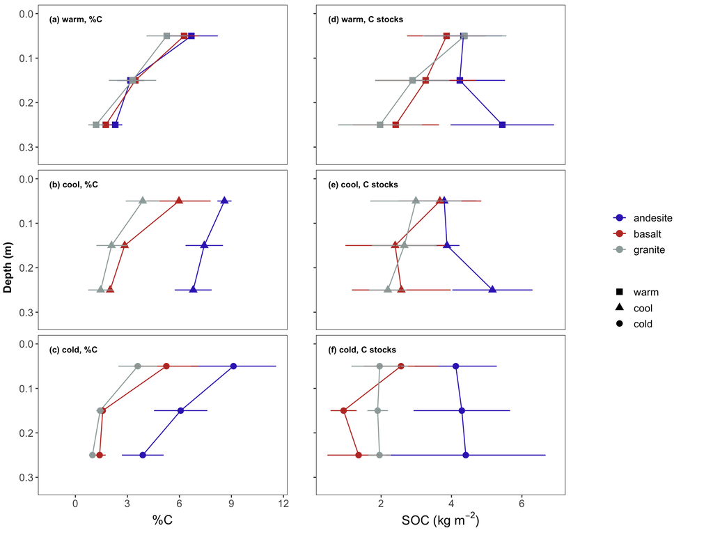

## Radiocarbon depth profiles

### Bulk soil

$\Delta$<sup>14</sup>C<sub>*bulk*</sub> covaried with both parent material and climate. We observed the most enriched $\Delta$<sup>14</sup>C<sub>*bulk*</sub> at the warm climate sites, indicating a preponderance of relatively young, fast-cycling C. However, contrary to what would be expected from the decomposition-temperature relationship, we observed the oldest soil C (i.e. most depleted $\Delta$<sup>14</sup>C<sub>*bulk*</sub> values) at the intermediate MAT cool climate sites rather than at the cold climate sites (**Fig. @ref(fig:blk-inc-pro-19), b, c**) (**Fig. @ref(fig:blk-inc-pro-19), a**). When comparing $\Delta$<sup>14</sup>C<sub>*bulk*</sub> from different parent materials within a given climate zone, $\Delta$<sup>14</sup>C<sub>*bulk*</sub> of andesitic soils tended to be the most depleted, while the granitic soils tended to be the most enriched (**Fig. @ref(fig:blk-inc-pro-19)**). We focus on the 2019 data here for simplicity, but $\Delta$<sup>14</sup>C<sub>*bulk*</sub> profiles showed similar patterns in both 2001 (**SI Fig. 2**) and 2009 (Rasmussen et al., 2018).

### Heterotrophically respired CO<sub>2</sub>

The effect of climate on $\Delta$<sup>14</sup>C<sub>respired</sub> appeared to be moderated by parent material. Accordingly, we did not observe significant differences in $\Delta$<sup>14</sup>C<sub>*respired*</sub> among the andesitic soils when compared across climate zones at any depth (SI Table XX Tukey results for emm). In contrast, $\Delta$<sup>14</sup>C<sub>*respired*</sub> diverged substantially between climate zones for the basaltic and granitic soils, particularly for the 0.1-0.2 m and 0.2-0.3 m depth layers (**Fig. @ref(fig:blk-inc-pro-19)**). Overall, $\Delta$<sup>14</sup>C<sub>*respired*</sub> values across sites were most similar at the soil surface (0-0.1 m), and most divergent at the intermediate depth (0.1-0.2 m) (**Fig. @ref(fig:blk-inc-pro-19)**).

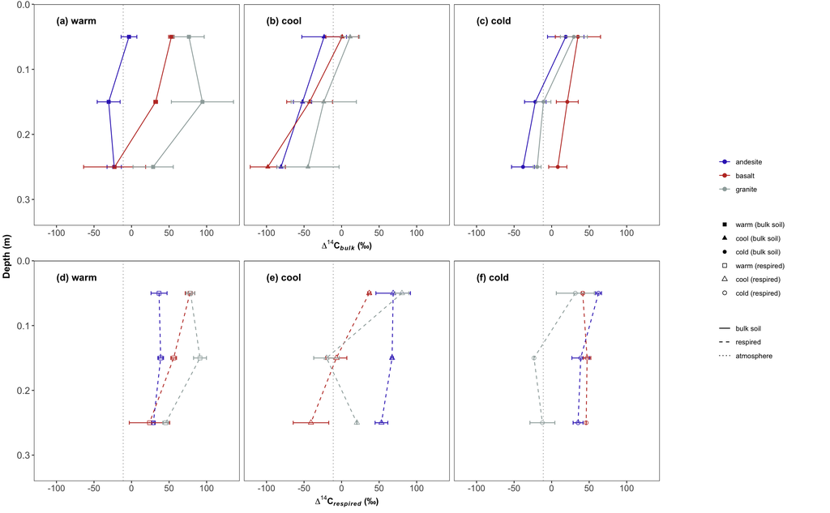

## Radiocarbon time series

[output not shown]

(ref:models-anova-cap) ANOVA for $\Delta$<sup>14</sup>C<sub>*bulk*</sub> and $\Delta$<sup>14</sup>C<sub>*respired*</sub>

| Depth | Predictor | Bulk soil $df$ | Bulk soil $F$ | Bulk soil $p$ | Respiration $df$ | Respiration $F$ | Respiration $p$ |
| --- | --- | --- | --- | --- | --- | --- | --- |
| 0-10cm | Parent material | 2 | 12.00 | \textbf{< .001} | 2 | 0.04 | 0.958 |
|  | Climate | 2 | 32.34 | \textbf{< .001} | 2 | 14.02 | \textbf{< .001} |
|  | Year | 1 | 32.03 | \textbf{< .001} | 1 | 75.29 | \textbf{< .001} |
|  | Parent material:Climate | 4 | 8.75 | \textbf{< .001} | 4 | 7.90 | \textbf{0.001} |
|  | Parent material:Year | 2 | 2.38 | 0.105 | 2 | 1.93 | 0.177 |
|  | Climate:Year | 2 | 6.61 | \textbf{0.003} | 2 | 2.26 | 0.137 |
|  | Parent material:Climate:Year | 4 | 5.19 | \textbf{0.002} | 4 | 3.75 | \textbf{0.024} |
|  | Residuals | 44 |  |  | 16 |  |  |
| 20-30cm | Parent material | 2 | 15.58 | \textbf{< .001} | 2 | 0.92 | 0.421 |
|  | Climate | 2 | 11.61 | \textbf{< .001} | 2 | 0.77 | 0.483 |
|  | Year | 1 | 1.30 | 0.26 | 1 | 0.65 | 0.434 |
|  | Parent material:Climate | 4 | 1.71 | 0.165 | 4 | 4.33 | \textbf{0.019} |
|  | Parent material:Year | 2 | 1.56 | 0.222 | 2 | 0.86 | 0.446 |
|  | Climate:Year | 2 | 4.04 | \textbf{0.024} | 2 | 1.41 | 0.278 |
|  | Parent material:Climate:Year | 4 | 0.98 | 0.43 | 2 | 0.37 | 0.698 |
|  | Residuals | 44 |  |  | 13 |  |  |

### Heterotrophically respired CO<sub>2</sub>

[output not shown]

±

| year.trend_sd |
| --- |
| 2 |

| year.trend_mean |
| --- |
| -2.7 |

±

| year.trend_sd |
| --- |
| 1.2 |

| year.trend_mean |
| --- |
| -2.2 |

±

| year.trend_sd |
| --- |
| 2.1 |

## Relationship of bulk soil and respired CO<sub>2</sub> $\Delta$<sup>14</sup>C

[output not shown]

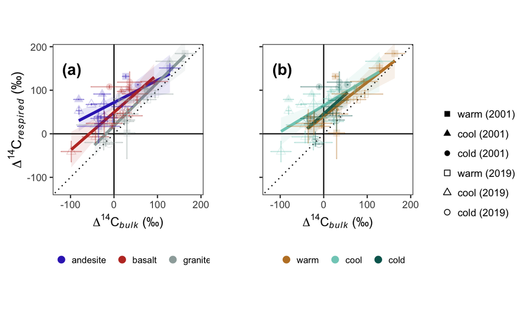

## Mineral assemblages and radiocarbon

Mineral assemblage data is reported fully in Rasmussen et al. (2018). Here we focus on the selective dissolution data with respect to the trends we observed in $\Delta$<sup>14</sup>C<sub>*bulk*</sub>, $\Delta$<sup>14</sup>C<sub>*respired*</sub>, and $\Delta$<sup>14</sup>C<sub>*respired-bulk*</sub>. We observed a significant negative correlation between $\Delta$<sup>14</sup>C<sub>*bulk*</sub> and the concentration of oxalate extractable iron, oxalate extractable aluminum, and pyrophosphate extractable aluminum (SI). For simplicity, we focus here on the sum of oxalate extractable aluminum and half of the oxalate extractable iron as a proxy for non-crystalline metal oxide abundance, and the difference of dithionite-citrate extractable iron and ammonium-oxalate extractable iron as a proxy for crystalline Fe-oxide abundance. The relationship between non-crystalline oxide abundance and $\Delta$<sup>14</sup>C<sub>*bulk*</sub> was highly significant (*p* <0.001), while the relationship between crystalline Fe-oxide abundance and $\Delta$<sup>14</sup>C<sub>*bulk*</sub> was not significant (**Fig. @ref(fig:plot-min-14c-0-30-blk-inc)**).

We observed a significant relationship between $\Delta$<sup>14</sup>C<sub>*respired*</sub> and poorly crystalline metal oxide abundance for the 2001 samples (*p* = 0.043), but not for the 2019 samples. Accordingly, the combined set of 2001 and 2019 data was only marginally significant(*p* = 0.066). However, we did see a highly significant relationship between poorly crystalline metal oxide abundance and $\Delta$<sup>14</sup>C<sub>*respired-bulk*</sub> (**Fig. @ref(fig:plot-min-14c-0-30-blk-inc), a**). As with $\Delta$<sup>14</sup>C<sub>*bulk*</sub>, there was no relationship with crystalline Fe-oxide abundance for either $\Delta$<sup>14</sup>C<sub>*respired*</sub> or $\Delta$<sup>14</sup>C<sub>*respired-bulk*</sub> (**Fig. @ref(fig:plot-min-14c-0-30-blk-inc), b**).

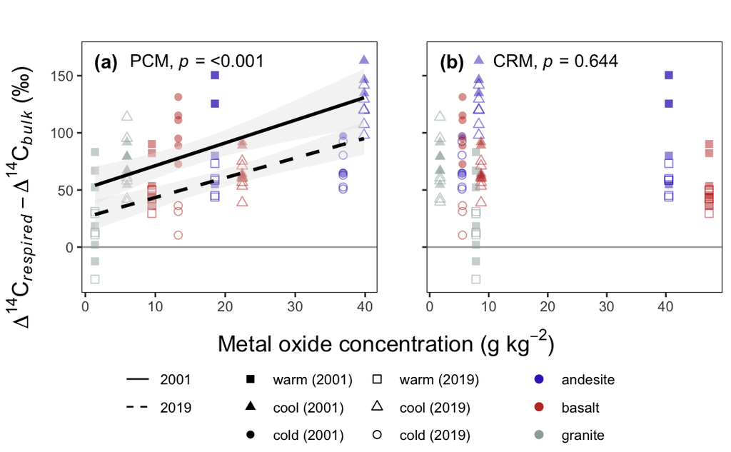

# Discussion

Climatic and mineralogical factors both play key roles in soil carbon persistence. However, the relevance of parent material for explaining soil organic matter persistence in soils with mixed mineralogies is still poorly explained. In the current study we illuminate how parent material interactions with climate lead to the development of distinct mineral assemblages, which in turn control the dynamics of soil C cycling at timescales ranging from annual to centennial. Our key findings are that soil mineral characteristics mediate climatic controls on soil C cycling, and that mineralogical controls on soil C cycling are not limited to soil C persistence on centennial timescales, but are relevant for C cycling on shorter timescales as well.

Our results challenge the primacy of climatic controls on soil carbon persistence, insofar as we observed the most depleted $\Delta$<sup>14</sup>C<sub>*bulk*</sub> in soils of the cool climate zone, not the cold climate zone. We found that climate is a critical factor for explaining the dynamics of both persistent and more transient soil C pools, as measured by proxy with $\Delta$<sup>14</sup>C<sub>*bulk*</sub> and $\Delta$<sup>14</sup>C<sub>*respired*</sub>, respectively. However, our results indicate that soil mineral characteristics moderate the strength of the climate effect. This is particularly apparent at depth. These results are supported by a recent study in which the authors used a depth-resolved model with energy and substrate limitation prescribed by Michalis Menten kinetics to model profiles of $\Delta$<sup>14</sup>C<sub>*bulk*</sub> (Ahrens et al. 2020). The authors found that site mean annual temperature could only explain a minimal amount of variation in the observed radiocarbon profiles, while varying sorption potential in the model allowed for a superior fit.

The soils with the largest difference between $\Delta$<sup>14</sup>C<sub>*respired*</sub> and $\Delta$<sup>14</sup>C<sub>*bulk*</sub> were those that had both strongly depleted values of $\Delta$<sup>14</sup>C<sub>*bulk*</sub> and values of $\Delta$<sup>14</sup>C<sub>*respired*</sub> that were enriched relative to the atmosphere. If we employ a theoretical compartmental model to interpret this finding, a possible scenario would involve one pool of centennial to millennial cycling soil C whose signal dominates the $\Delta$<sup>14</sup>C<sub>*bulk*</sub> signal, and second pool of soil C enriched with C fixed from the atmosphere in the years immediately following the bomb-C spike, e.g. 1964 to 1990, whose signal dominates the $\Delta$<sup>14</sup>C<sub>*respired*</sub> signal. More complex model structures could potentially be fit to these data, but the data provide clear evidence for the presence of at least two distinct pools with strongly depleted C largely inaccessible to the microbial community, and another pool enriched with decadally cycling C dominating the respiration flux. This stands in contrast to the soils with $\Delta$<sup>14</sup>C<sub>*respired*</sub> values close to that of the atmosphere, in which the respired signal is likely dominated by sub-decadally cycling C.

Laboratory studies on soil organic matter associations with poorly crystalline metal oxides such as goethite show that only a portion of the organic matter is so tightly bound as to resist desorption (Kaiser and Guggenberger, 2003). Further studies have demonstrated that a portion of the organic matter can be mobilized by exchange with DOC (Leinemann et al., 2018). In this scenario the highly depleted $\Delta$<sup>14</sup>C<sub>*bulk*</sub> values observed in the soils with high concentrations of poorly crystalline minerals may derive from organic matter that is strongly sorbed or trapped in micropores, while the bomb-C enriched decadally cycling C observed in the respiration flux could derive from the more microbially accessible and DOC-exchangeable mineral associated soil C pool. However, the rates of change over time that we observed for $\Delta$<sup>14</sup>C<sub>*respired*</sub> indicate that annually cycling C is also an important component of soil organic matter at all of our sites.

In contrast to what we observed for the poorly crystalline metal oxides, the lack of correlation we observed between crystalline Fe oxides and soil radiocarbon suggests that these minerals do not play an important role in explaining soil C persistence, at least in these soils. Other studies have shown that crystalline Fe oxides do protect soil C from microbial decomposition, but that the overall sorption capacity of these mineral species is low [Kahle et al., 2003]. We observed a large increase in the amount of iron released from crystalline minerals (via selective dissolution) at the warm sites relative to the cool or cold sites, along with a corresponding decrease in soil C concentration and relative enrichment in both $\Delta$<sup>14</sup>C<sub>*bulk*</sub> and $\Delta$<sup>14</sup>C<sub>*respired*</sub>. This increase in crystalline iron was also associated with a corresponding decrease in the abundance of poorly crystalline metal oxides. Together these trends suggest that these soils have lost poorly crystalline metal oxides through leaching and transformation into crystalline species. The patterns of C concentrations and associated SOC stocks, $\Delta$<sup>14</sup>C<sub>*bulk*</sub>, and $\Delta$<sup>14</sup>C<sub>*respired*</sub> observed across the climate/weathering gradient suggest that weathering of poorly crystalline metal oxides leads to a reduction in soil carbon stocks, which is caused by losses of old $\Delta$<sup>14</sup>C depleted carbon associated with these minerals, and that this process is relevant across a range of igneous parent materials.

The sensitivity of decomposition to temperature is of particular interest for understanding how soil C dynamics may change under a warming climate. Comparing the change in $\Delta$<sup>14</sup>C<sub>*respired*</sub> over time for the different climate zones across the different lithologies provides insight into this question. Focusing on the near surface soils (0-0.1 m), where climate effects are strongest, we observed that the rate of change in $\Delta$<sup>14</sup>C<sub>*respired*</sub> over time was correlated with poorly crystalline metal oxide content. We observed a linear relationship between MAT and the rate of change in $\Delta$<sup>14</sup>C<sub>*respired*</sub> over time for the granitic soils, which had low concentrations of poorly crystalline metal oxides in all three climate zones. In contrast, $\Delta$<sup>14</sup>C<sub>*respired*</sub> changed more over time in the coldest climate zone for the basaltic and andesitic soils than in the cool climate zone with higher concentrations of poorly crystalline metal oxides. Furthermore, the change in $\Delta$<sup>14</sup>C<sub>*respired*</sub> over time was similar for all three parent materials at the warm climate zone with minimal poorly crystalline metal oxide content. These findings provide evidence that the temperature sensitivity of soil organic matter decomposition may be attenuated in the presence of poorly crystalline minerals. If this is true, we would expect that potential increases in decomposition rates, and accompanying carbon losses due to climate warming, would be greater in soils lacking substantial concentrations of poorly crystalline metal oxides than in soils enriched in these minerals.

# Conclusion

The effect of the interaction between parent material and climate on soil C dynamics is best explained by the development of distinct mineral assemblages via weathering, in particular the formation and subsequent loss of poorly crystalline metal oxides. We confirm the findings of other studies showing that poorly crystalline minerals are highly correlated with the age of soil C, as measured by proxy with $\Delta$<sup>14</sup>C<sub>*bulk*</sub>. We extend this finding to show that it is specifically the poorly crystalline metal oxide content that is correlated with $\Delta$<sup>14</sup>C<sub>*bulk*</sub>, and that the correlation with crystalline Fe content is not significant. Furthermore, we provide mechanistic evidence for the protective effect of mineral-association on decomposition of soil organic matter by demonstrating that the difference between $\Delta$<sup>14</sup>C<sub>*bulk*</sub> and $\Delta$<sup>14</sup>C<sub>*respired*</sub> is highly correlated with poorly crystalline mineral content. Finally, the signal from decadally cycling soil C in $\Delta$<sup>14</sup>C<sub>*respired*</sub> from the sites enriched with poorly crystalline metal oxides provides preliminary evidence that the association of soil organic matter with these mineral phases may attenuate the temperature sensitivity of decomposition.

In future work we intend to quantify the timescales of soil carbon cycling in mineral and non-mineral associated pools with a compartmental modeling approach, using the radiocarbon time series presented here in addition to radiocarbon measurements of soil density and thermal fractions as constraints. With this modeling framework we also hope to test additional hypotheses regarding mineral association and temperature sensitivity of soil organic matter.